# Probability

Jessi Kehe

This R Markdown document was adapted from documents created by Professor Bret Larget.

### Setup details

- You will need the package `tidyverse` for these lectures.
- This assumes you have the R script `viridis.R` two steps back from the working directory (`"../../scripts/viridis.R"`). Be sure to adjust the code if you have this script in a different location.

# Lecture: Probability Distributions

## Uncertainty

- To this point in the semester, we have largely ignored uncertainty in our data.
- But there are many sources and types of uncertainty we could consider:
  - measurement error  
    - freeze dates of Madison lakes are partly subjective  
    - weather observations are susceptible to error
  - unobserved data from unsampled cases in a population  
    - In the obesity study, we had obesity data on samples of individuals
  - rerunning a random process - We can think of the outcome of a sports event as a complicated succession of random events  
    - If the same players and teams could replay a game under the same conditions, how might have outcomes been different?
  - prediction  
    - What will the temperature be like tomorrow? Next year?  
    - How many fantasy football points will Aaron Rodgers earn during the next game?  
    - What will the median household income in zip code 53705 be next year?
- To discuss uncertainty, we need to develop an understanding of the subject of probability.

## Probability

- Probability is a branch of mathematics
- We will learn the subject quite informally
  - If you are interested in majoring in a quantitative field, I recommend taking a semester-long course in probability at some point in the future (if you haven’t already)
- Our overview of probability will focus on understanding uncertainty in statistical models.
- A statistical model will be a means to connect data with uncertainty to build a framework for inference.

## Philosophical Views of the Nature of Probability

- Probability is measured on a scale from 0 (no chance of occurring) to 1 (certain to occur).
- One school of thought attaches a long-run frequency interpretation to probabilities
  - When a fair 6-sided die is rolled, the long-run frequency of observing a 1 is 1/6, so the probability of observing a 1 on any given doe roll is 1/6.
  - We arrive at 1/6 from an argument of symmetry and a model for “fairness”, not from actually rolling a physical die an infinite number of times.
- Not all events to which we wish to attach probabilities are as easily thought of as infinitely repeatable.
  - What is the probability that the high temperature will be above 40 degrees F tomorrow in Madison, WI?
  - What is the probability that Aaron Rodgers will have more than 250 yards passing in his next football game?
  - What is the probability that the Dow Jones average will go up over 500 points between now and the end of the year?
- An alternative philosophical approach to probability describes a degree of belief with formal rules on how probabilities are updated when presented new information.
  - This Bayesian approach to probability is widely applicable, even in cases where a long-run frequency interpretation is challenging.
  - The Bayesian approach does require the statement of prior probability distributions, or statements about probability prior to seeing data.
- Regardless of the philosophical point of view adopted, we will apply principles of probability to applications of statistical models.

## Basic Principles of Probability

- A probability space is a mathematical formalism that specifies how to attach probabilities to a collection of possible outcomes and events
- The basic rules are:
  - the probability of any possible event is greater than or equal to zero
  - the probability that some outcome from the collection of all possible outcomes occurs is one
  - the probability of the union of mutually exclusive events is the sum of the individual probabilities
- There are a number of rules that follow from these basic principles

## Random Variables

- A random variable is a function that attaches a numerical value to some random outcome.
  - The weather in Madison will result in an observed maximum temperature
  - On December 31, 2030, Lake Mendota will either be closed (at least 50% of the surface covered by ice) or not – an indicator random variable takes the value 1 if it is closed and 0 if it is not.
  - In his next football game, Aaron Jones will have some number of yards rushing
  - For all US passengers arriving at O’Hare International airport today on flights that arrive between 5 and 6 pm, the average waiting time to go through customs will have a numerical value.
- The collection of all possible values that a random variable might take and the description of the probabilities of these outcomes is called the *distribution* of the random variable.
- In practice, most distributions of random variables may be categorized as either:
  - continuous (possible values along a continuum, but in practice, rounded to some degree of precision during measurement); or
  - discrete (we can list the possible values, which are potentially infinite)
- There are exceptions which are a mix
  - the total amount of precipitation in a day could be zero (discrete) or some positive amount (continuous).
- A distribution describes where the total amount of probability is distributed among the possible values.

### Continuous Distributions

For continuous random variables, we typically describe the distribution with a *probability density function* (pdf), a nonnegative function over the real line with a total area under the curve equal to one

- Probability is associated with areas over intervals under density curves to describe the probability that the random variables take a value in the interval
- There do exist continuous random variables not often seen in statistical models for which density functions do not exist
  - Graduate courses in probability theory which require a lot more mathematics than we have are needed to study such distributions

#### Example

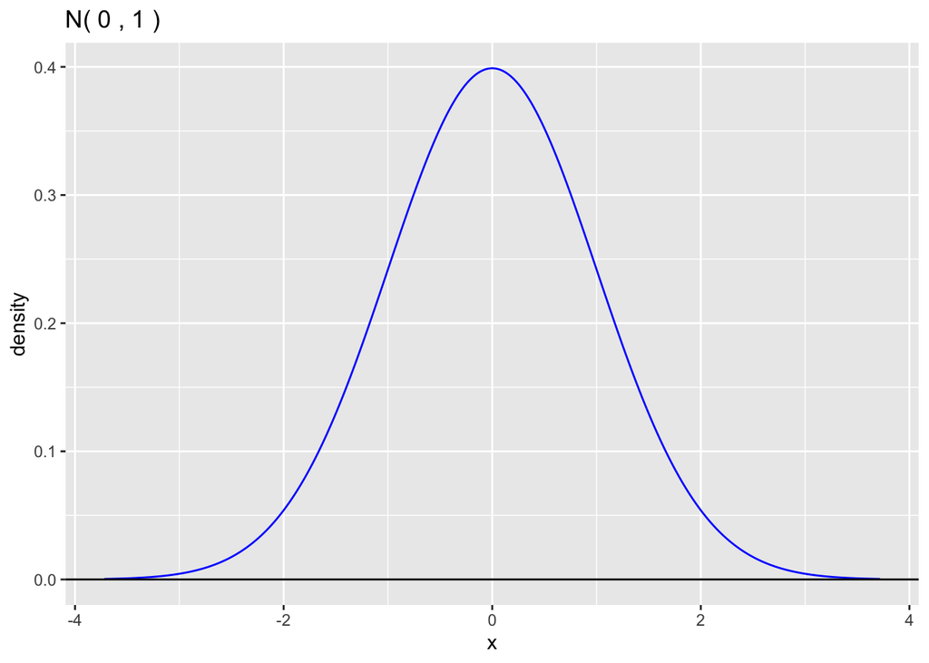

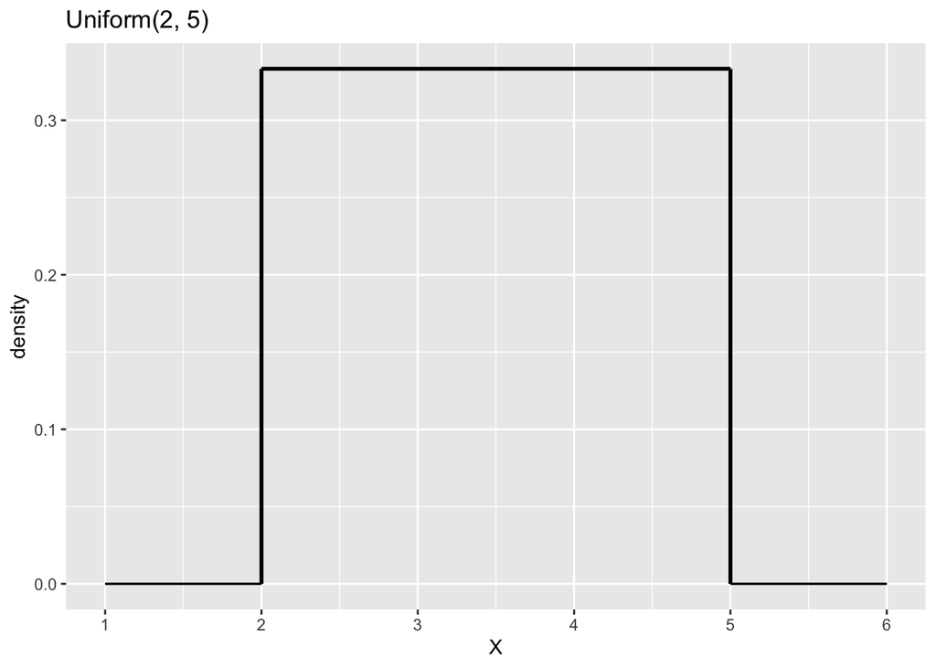

### Discrete Distributions

For discrete random variables, we typically describe the distribution with a *probability mass function* (pmf), a nonnegative function that attaches discrete amounts of probability to specific real numbers in a way that the sum of all such probabilities over all possible values of the random variable is equal to one.

#### Example

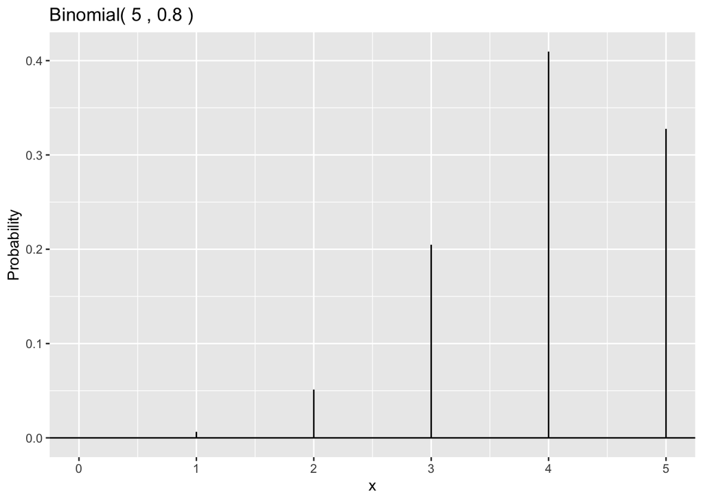

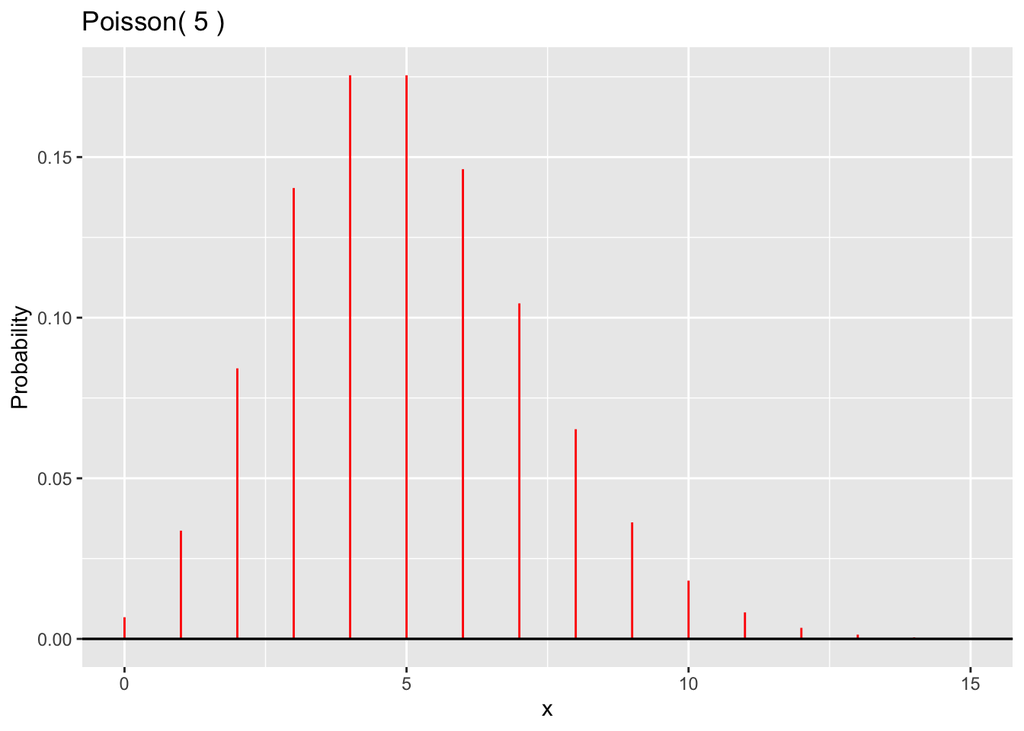

### Mixed Distributions

A mixed variable such as the total precipitation in a day, has a distribution that is a combination of discrete probability mass and continuous probability density such that the total amount of probability is equal to one.

## Expectation

- Expectation is a probability concept that you may think of as average.
- The expected value of a random variable is:  
  - the balancing point of the distribution  
  - the value of the sample mean tends to the expected value as the sample size goes to infinity  
  - the mean of the possible values, weighted by their probability
- If a random variable is designated $X$, we label its expected value $E(X)$
- We can also take the expected value of a function of a random variable  
  - For example, the expected value of the square of a random variable, $E(X^2)$

### Mean

- The mean of a random variable $X$ is $E(X)$
- We often use the Greek letter $\mu$ to represent a mean
- Some distributions do not have a finite mean  
  - We do not see these often in statistical models

### Standard Deviation / Variance

- The variance of a random variable is the expected squared difference from the mean.
- $\text{Var}(X) = E\left((X-\mu)^2\right)$ where $\mu = E(X)$
- The standard deviation is the square root of the variance.
- The variance is often denoted $\sigma^2$
- The standard deviation is then denoted as $\sigma$
- By definition, the variance and the standard deviation cannot be negative.

# Lecture: Binomial Distribution

## Binomial Distribution

Binomial distributions are discrete distributions that consider the number of “successes” in a fixed series of n trials.

Example: Flipping a coin 10 times and recording the number of heads (successes) would follow a binomial distribution with n = 10 and probability of success p = .5 (assuming the coin is fair!).

- Binomial distributions are used when we want to know about the occurrence of an event, not its magnitude.
  - In a clinical trial, a patient’s condition may improve or not. The binomial distribution would model the number of patients who improved, not how much better they feel.

#### The BINS acronym for binomial assumptions

A binomial random variable satisfies the following properties:

- B = **binary outcomes** (each trial may be categorized with two outcomes, conventionally labeled *success* and *failure*)
- I = **independence** (results of trials do not affect probabilities of other trial outcomes)
- N = **fixed sample size** (the sample size is prespecified and not dependent on outcomes)
- S = **same probability** (each trial has the same probability of *success*)

## Binomial Parameters

- There are two parameters for the binomial distribution:
  - $n$ which is the number of trials
  - $p$ which is the *success* probability
- If X follows a binomial distribution with parameters $n$ and $p$, we write $X \sim Bin(n, p)$

## Binomial Moments

- The mean is $\mu =np$
- The variance is $\sigma^2 = np(1-p)$
- The standard deviation is $\sigma = \sqrt{np(1-p)}$

## Explore Binomial Graphs

```r
n_options <- 2^seq(0, 12, by=2) # sample sizes to consider
p_options <- c(.5, .1)  # probabilities to consider

for(p in p_options){
  par(mfrow = c(2,4))
  for(n in n_options){
    print(gbinom(n,p,color=ifelse(p==.5,"red","blue")) )
  }
  print(gbinom(n,p,color=ifelse(p==.5,"red","blue"),scale=TRUE) )
}
```

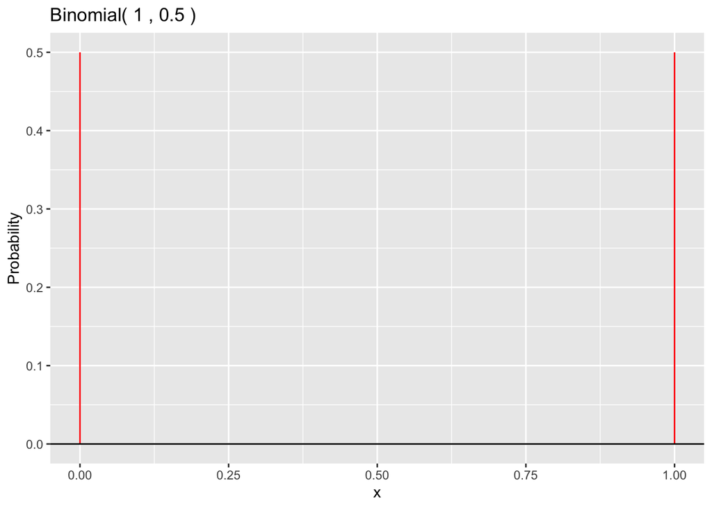

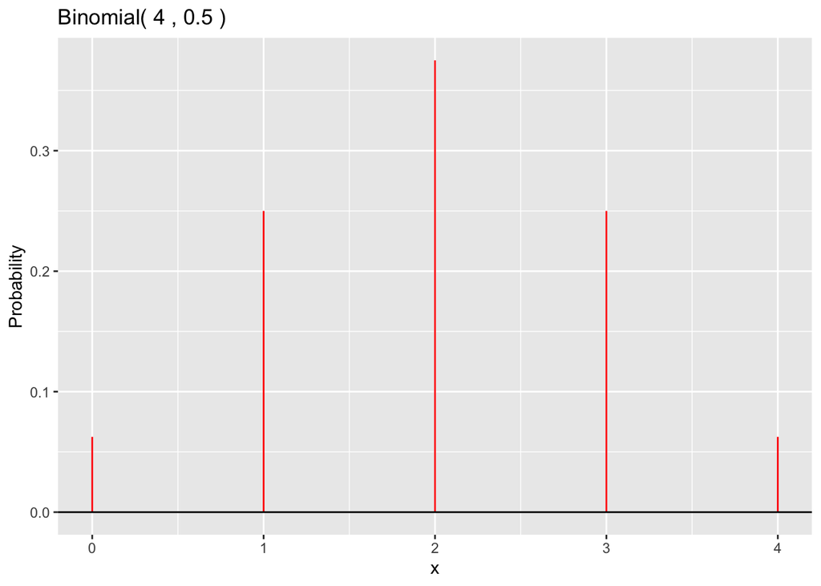

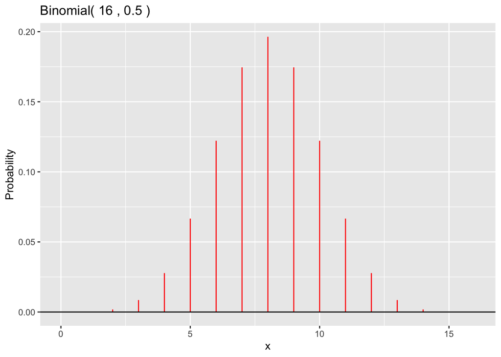

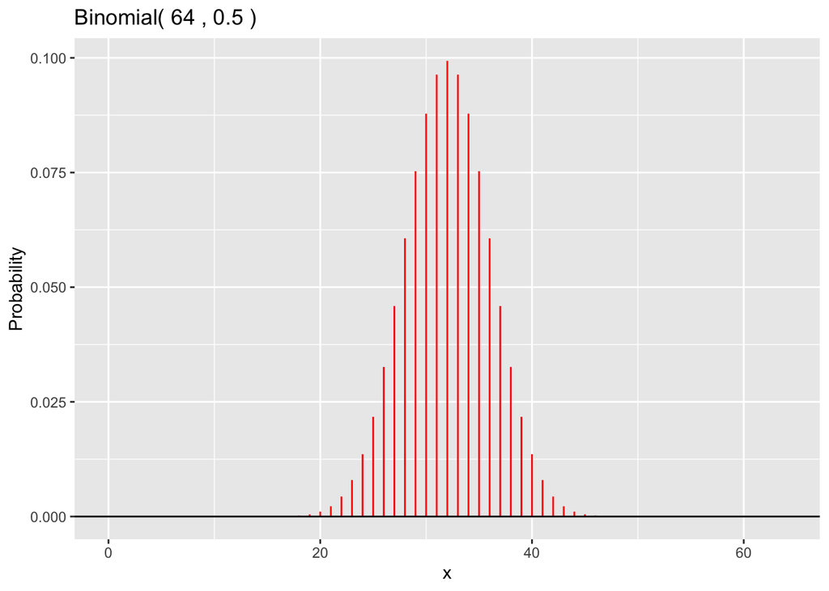

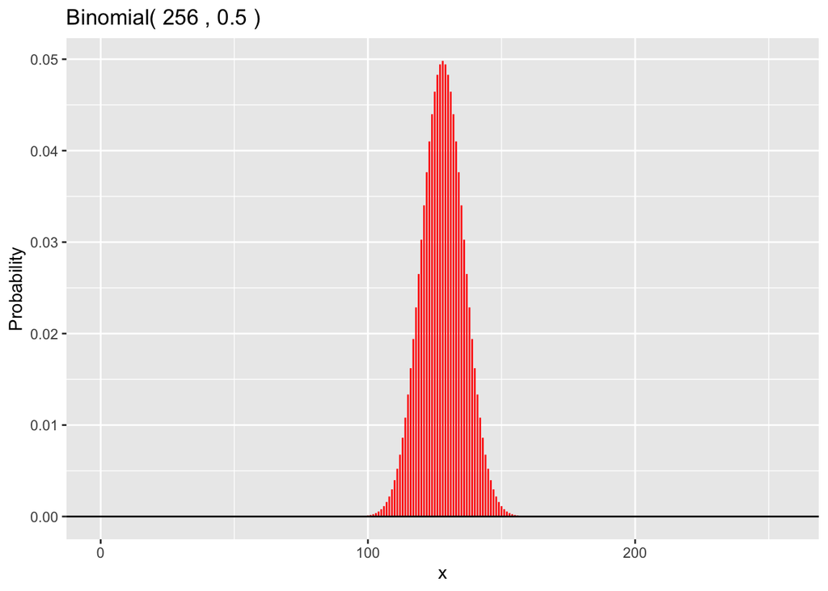

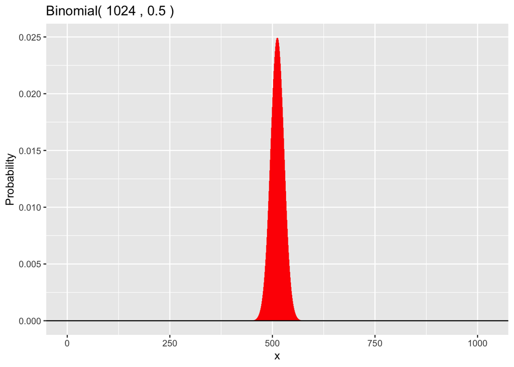

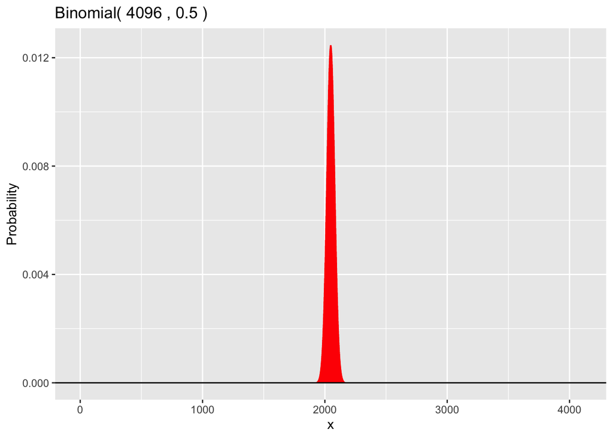

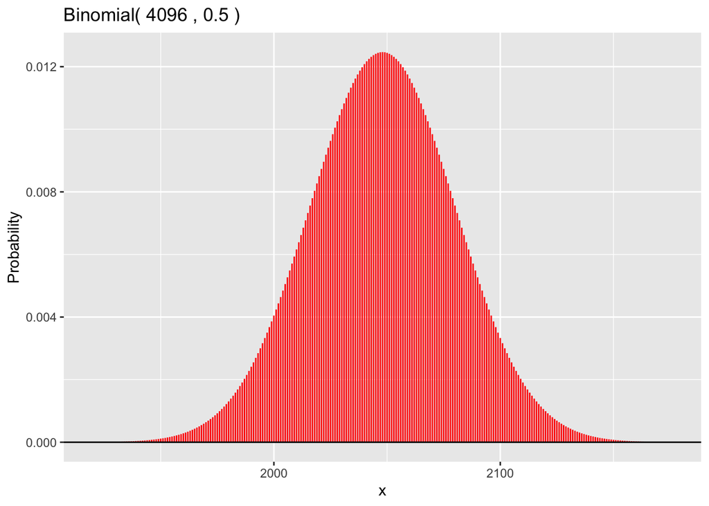

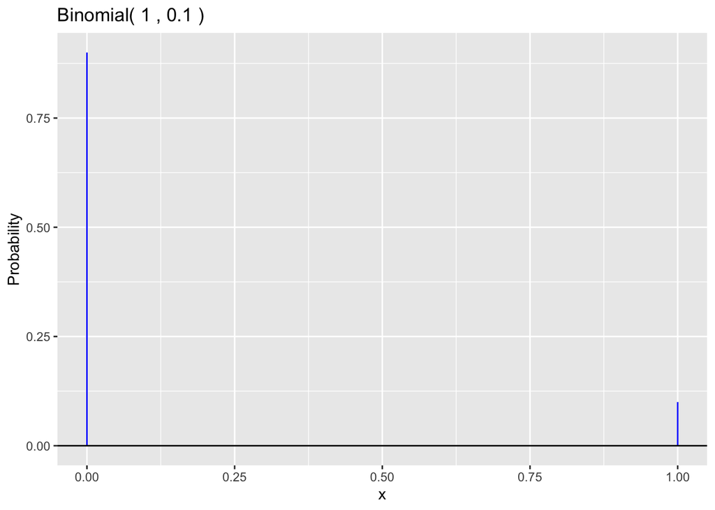

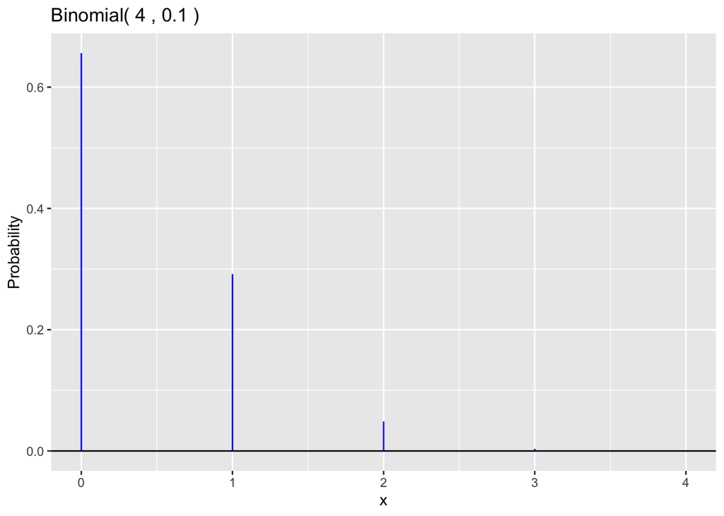

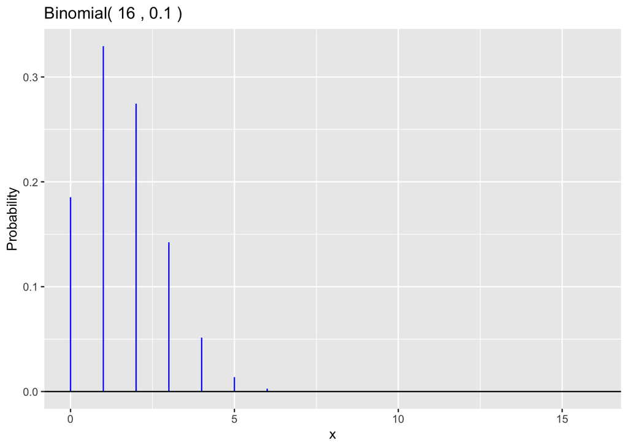

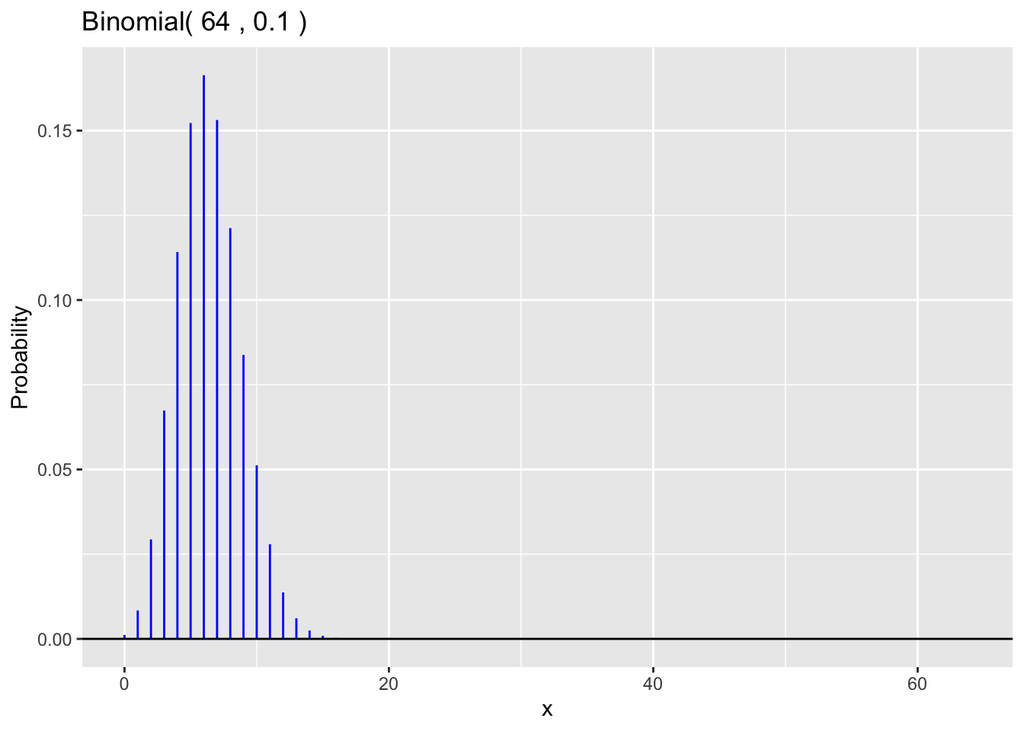

[4 more figures not shown]

## Binomial Probabilities

$$P(X = k) = \binom{n}{k} p^k(1-p)^{n-k}, \qquad \text{for $k=0,1,\ldots,n$}$$

```r
n <- 5
p <- .5
k <- 2

choose(n, k)
```

```
## [1] 10
```

```r
factorial(n)/(factorial(k)*factorial(n-k))
```

```
## [1] 10
```

```r
choose(n, k)*p^k*(1-p)^(n-k)
```

```
## [1] 0.3125
```

```r
dbinom(k,n,p) # see below
```

```
## [1] 0.3125
```

## R Binomial Functions

- `rbinom(n, size, prob)`
- `dbinom(x, size, prob)`
- `pbinom(q, size, prob)`
- `qbinom(p, size, prob)`

Note that with these functions, the parameters for the Binomial are `size` and `prob` (what we’ve been referring to as n and p, respectively)

#### Demonstrations

```r
# Simulate binomial random variables
n <- 5
p <- .5
(x <- rbinom(6, n, p))
```

```
## [1] 1 1 3 2 4 4
```

```r
mean(x)
```

```
## [1] 2.5
```

```r
n*p
```

```
## [1] 2.5
```

```r
var(x)
```

```
## [1] 1.9
```

```r
n*p*(1-p)
```

```
## [1] 1.25
```

```r
## Binomial "density" calculations
dbinom(0:n, n, p)
```

```
## [1] 0.03125 0.15625 0.31250 0.31250 0.15625 0.03125
```

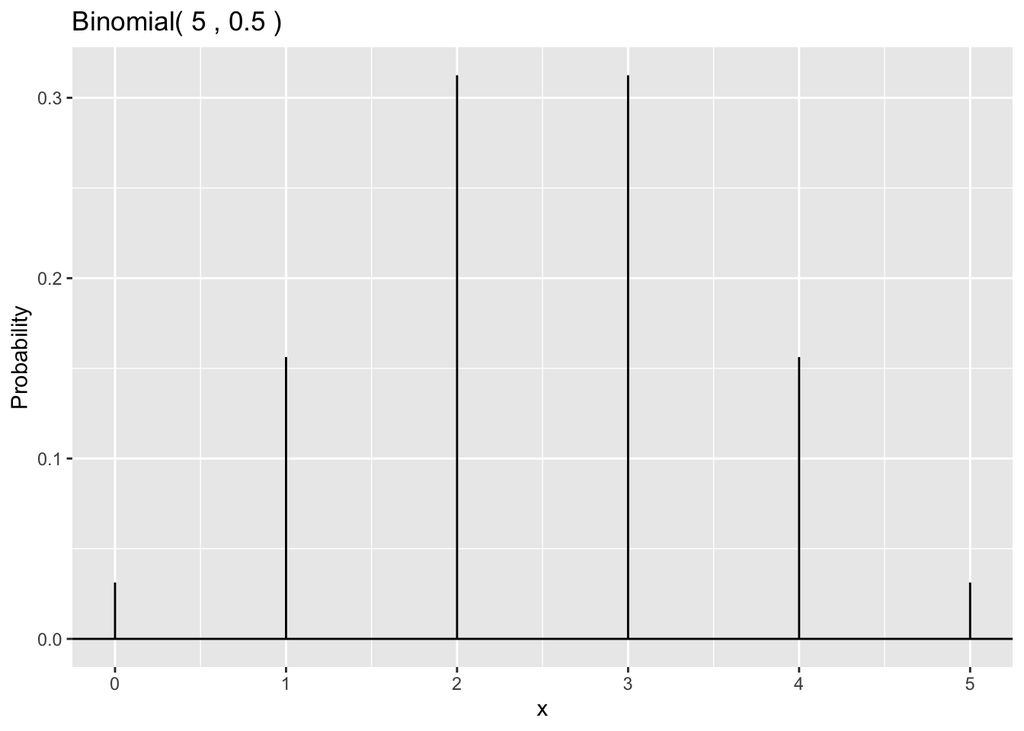

```r
## Binomial "density" plot
gbinom(n,p)
```

```r
## Binomial distribution calculations
## P(X <= x) = F(x), where F is the distribution function.

# P(X <= 3):
pbinom(3, n, p)
```

```
## [1] 0.8125
```

```r
dbinom(0, n, p) + dbinom(1, n, p) + dbinom(2, n, p) + dbinom(3, n, p)
```

```
## [1] 0.8125
```

```r
1 - dbinom(4, n, p) - dbinom(5, n, p)
```

```
## [1] 0.8125
```

```r
# P(X > 3):
1 - pbinom(3, n, p)
```

```
## [1] 0.1875
```

```r
pbinom(3, n, p, lower.tail=FALSE)
```

```
## [1] 0.1875
```

```r
dbinom(4, n, p) + dbinom(5, n, p)
```

```
## [1] 0.1875
```

```r
# P(X < 3):
pbinom(3, n, p) - dbinom(3, n, p)
```

```
## [1] 0.5
```

```r
pbinom(2, n, p) # P(X <= 2)
```

```
## [1] 0.5
```

```r
## Binomial quantile calculations
## Docs:  The quantile is defined as the smallest value x such that F(x) ≥ p, where F is the distribution function.
qbinom(.2, n, p)
```

```
## [1] 2
```

```r
dbinom(0, n, p) + dbinom(1, n, p) + dbinom(2, n, p)
```

```
## [1] 0.5
```

# Lecture: Normal Distribution

## Overview

- Normal distributions are continuous distributions
- All normal distributions have the same overall shape: symmetric, unimodal, bell-shaped
- The shape of the normal density curve is completely determined by its mean ($\mu$) and its standard deviation ($\sigma$):

$$f(x) = \frac{1}{\sigma\sqrt{2\pi}} e^{-\frac{1}{2}\left(\frac{x-\mu}{\sigma}\right)^2}$$
* The mean $\mu$ is located at the center and the standard deviation $\sigma$ controls the spread.

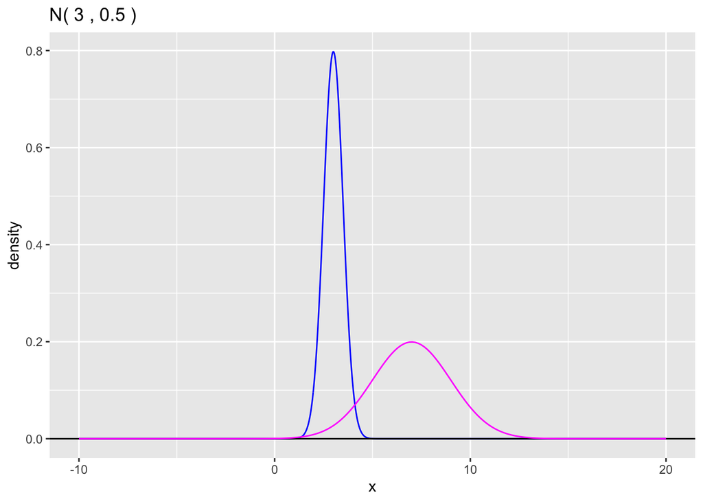

```r
mu <- 3
sigma <- .5
mu2 <- 7
sigma2 <- 2

gnorm(mu=mu,sigma=sigma,a=-10,b=20,color="blue", fill=NULL,title=TRUE)+
  stat_function(fun = dnorm, n = 200, args = list(mean = mu2, sd = sigma2), color="magenta")
```